# Adult Dataset Income Prediction using Simple Classification Techniques

Rohit Amalnerkar

10/12/2019

**Data Set Information:**

**Objective:**

The main objective of the dataset is to classify people earning <=50k or >50k based on several explanatory factors affecting the income of a person like Age, Occupation, Education, etc.

The methods we intend to use are:

- Binary Logistic Regression
- Decision Tree
- Random Forest

Data cleaning method used in this article is **kNN imputation using VIM library**

**Understanding the Data set:**

- age: The age of an individual
- workclass: A general term to represent the employment status of an individual.

  ```
            * Private
            * Self.emp.not.inc
            * Self.emp.inc
            * Federal.gov
            * Local.gov
            * State.gov
            * Without.pay
            * Never.worked.
  ```

- fnlwgt: Final weight. In other words, this is the number of people the census believes the entry represents.
- education: The highest level of education achieved by an individual.

  ```
             * Bachelors
             * Some.college
             * 11th
             * HS.grad
             * Prof.school
             * Assoc.acdm
             * Assoc.voc
             * 9th
             * 7th.8th
             * 12th
             * Masters
             * 1st.4th
             * 10th
             * Doctorate
             * 5th.6th
             * Preschool.
  ```

- education.num: The highest level of education achieved in numerical form.
- marital.status: Marital status of an individual. Married.civ.spouse corresponds to a civilian spouse while Married.AF.spouse is a spouse in the Armed Forces.

  ```
             * Married.civ.spouse
             * Divorced
             * Never.married
             * Separated
             * Widowed
             * Married.spouse.absent
             * Married.AF.spouse
  ```

- occupation: the general type of occupation of an individual

  ```
             * Tech.support
             * Craft.repair
             * Other.service
             * Sales
             * Exec.managerial
             * Prof.specialty
             * Handlers.cleaners
             * Machine.op.inspct
             * Adm.clerical
             * Farming.fishing
             * Transport.moving
             * Priv.house.serv
             * Protective.serv
             * Armed.Forces
  ```

- relationship: Represents what this individual is relative to others. For example an individual could be a Husband. Each entry only has one relationship attribute and is somewhat redundant with marital status. We might not make use of this attribute at all

  ```
             * Wife
             * Own.child
             * Husband
             * Not.in.family
             * Other.relative
             * Unmarried.
  ```

- race: Descriptions of an individual’s race

  ```
             * White
             * Asian.Pac.Islander
             * Amer.Indian.Eskimo
             * Other
             * Black
  ```

- sex: the biological sex of the individual

  ```
             * Male
             * Female
  ```

- capital.gain: capital gains for an individual
- capital.loss: capital loss for an individual
- hours.per.week: the hours an individual has reported to work per week
- native.country: country of origin for an individual

  ```
             * United.States
             * Cambodia
             * England
             * Puerto.Rico
             * Canada
             * Germany
             * Outlying.US(Guam.USVI.etc)
             * India
             * Japan
             * Greece
             * South
             * China
             * Cuba
             * Iran
             * Honduras
             * Philippines
             * Italy
             * Poland
             * Jamaica
             * Vietnam
             * Mexico
             * Portugal
             * Ireland
             * France
             * Dominican.Republic
             * Laos
             * Ecuador
             * Taiwan
             * Haiti
             * Columbia
             * Hungary
             * Guatemala
             * Nicaragua
             * Scotland
             * Thailand
             * Yugoslavia
             * El.Salvador
             * Trinadad&Tobago
             * Peru
             * Hong
             * Holand.Netherlands
  ```

- the label: whether or not an individual makes more than $50,000 annually.

  ```
             * <=50k
             * >50k
  ```

**Loading the data and performing EDA**

```r
adult<-read.csv("C:/Users/Rohit/Desktop/R/Data sets/adult.csv",header=T)
# header = T : if file with header is given then we use this arg (will not include first row for calculations)
#              if this arg is not added it will consider first row for calculations

head(adult) # to check the first 6 observations in the data
```

```
##   age workclass fnlwgt    education education.num marital.status
## 1  90         ?  77053      HS-grad             9        Widowed
## 2  82   Private 132870      HS-grad             9        Widowed
## 3  66         ? 186061 Some-college            10        Widowed
## 4  54   Private 140359      7th-8th             4       Divorced
## 5  41   Private 264663 Some-college            10      Separated
## 6  34   Private 216864      HS-grad             9       Divorced
##          occupation  relationship  race    sex capital.gain capital.loss
## 1                 ? Not-in-family White Female            0         4356
## 2   Exec-managerial Not-in-family White Female            0         4356
## 3                 ?     Unmarried Black Female            0         4356
## 4 Machine-op-inspct     Unmarried White Female            0         3900
## 5    Prof-specialty     Own-child White Female            0         3900
## 6     Other-service     Unmarried White Female            0         3770
##   hours.per.week native.country income
## 1             40  United-States  <=50K
## 2             18  United-States  <=50K
## 3             40  United-States  <=50K
## 4             40  United-States  <=50K
## 5             40  United-States  <=50K
## 6             45  United-States  <=50K
```

**EDA of the dependent variable**

The original dataset contains a distribution of 24.08% entries labeled with >50k and 75.91% entries labeled with <=50k. The following graphs and statistics pertain to the orignal dataset.

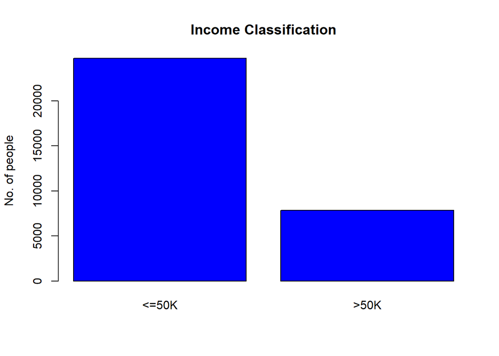

```r
library(ggplot2)
barplot(table(adult$income),main = 'Income Classification',col='blue',ylab ='No. of people')
```

Let’s check the summary of the data

```r
summary(adult)
```

```
##       age                   workclass         fnlwgt
##  Min.   :17.00   Private         :22696   Min.   :  12285
##  1st Qu.:28.00   Self-emp-not-inc: 2541   1st Qu.: 117827
##  Median :37.00   Local-gov       : 2093   Median : 178356
##  Mean   :38.58   ?               : 1836   Mean   : 189778
##  3rd Qu.:48.00   State-gov       : 1298   3rd Qu.: 237051
##  Max.   :90.00   Self-emp-inc    : 1116   Max.   :1484705
##                  (Other)         :  981
##         education     education.num                 marital.status
##  HS-grad     :10501   Min.   : 1.00   Divorced             : 4443
##  Some-college: 7291   1st Qu.: 9.00   Married-AF-spouse    :   23
##  Bachelors   : 5355   Median :10.00   Married-civ-spouse   :14976
##  Masters     : 1723   Mean   :10.08   Married-spouse-absent:  418
##  Assoc-voc   : 1382   3rd Qu.:12.00   Never-married        :10683
##  11th        : 1175   Max.   :16.00   Separated            : 1025
##  (Other)     : 5134                   Widowed              :  993
##            occupation           relationship                   race
##  Prof-specialty :4140   Husband       :13193   Amer-Indian-Eskimo:  311
##  Craft-repair   :4099   Not-in-family : 8305   Asian-Pac-Islander: 1039
##  Exec-managerial:4066   Other-relative:  981   Black             : 3124
##  Adm-clerical   :3770   Own-child     : 5068   Other             :  271
##  Sales          :3650   Unmarried     : 3446   White             :27816
##  Other-service  :3295   Wife          : 1568
##  (Other)        :9541
##      sex         capital.gain    capital.loss    hours.per.week
##  Female:10771   Min.   :    0   Min.   :   0.0   Min.   : 1.00
##  Male  :21790   1st Qu.:    0   1st Qu.:   0.0   1st Qu.:40.00
##                 Median :    0   Median :   0.0   Median :40.00
##                 Mean   : 1078   Mean   :  87.3   Mean   :40.44
##                 3rd Qu.:    0   3rd Qu.:   0.0   3rd Qu.:45.00
##                 Max.   :99999   Max.   :4356.0   Max.   :99.00
##
##        native.country    income
##  United-States:29170   <=50K:24720
##  Mexico       :  643   >50K : 7841
##  ?            :  583
##  Philippines  :  198
##  Germany      :  137
##  Canada       :  121
##  (Other)      : 1709
```

Now as we can see some of the values in coloumns are marked as ‘?’

Let us first convert these to NA while loading the data itself

```r
adult1<-read.csv("C:/Users/Rohit/Desktop/R/Data sets/adult.csv",na.strings = c("?","NA"))
# This will replace '?' with 'NA'

# Let's check summary again
summary(adult1)
```

```
##       age                   workclass         fnlwgt
##  Min.   :17.00   Private         :22696   Min.   :  12285
##  1st Qu.:28.00   Self-emp-not-inc: 2541   1st Qu.: 117827
##  Median :37.00   Local-gov       : 2093   Median : 178356
##  Mean   :38.58   State-gov       : 1298   Mean   : 189778
##  3rd Qu.:48.00   Self-emp-inc    : 1116   3rd Qu.: 237051
##  Max.   :90.00   (Other)         :  981   Max.   :1484705
##                  NA's            : 1836
##         education     education.num                 marital.status
##  HS-grad     :10501   Min.   : 1.00   Divorced             : 4443
##  Some-college: 7291   1st Qu.: 9.00   Married-AF-spouse    :   23
##  Bachelors   : 5355   Median :10.00   Married-civ-spouse   :14976
##  Masters     : 1723   Mean   :10.08   Married-spouse-absent:  418
##  Assoc-voc   : 1382   3rd Qu.:12.00   Never-married        :10683
##  11th        : 1175   Max.   :16.00   Separated            : 1025
##  (Other)     : 5134                   Widowed              :  993
##            occupation            relationship                   race
##  Prof-specialty : 4140   Husband       :13193   Amer-Indian-Eskimo:  311
##  Craft-repair   : 4099   Not-in-family : 8305   Asian-Pac-Islander: 1039
##  Exec-managerial: 4066   Other-relative:  981   Black             : 3124
##  Adm-clerical   : 3770   Own-child     : 5068   Other             :  271
##  Sales          : 3650   Unmarried     : 3446   White             :27816
##  (Other)        :10993   Wife          : 1568
##  NA's           : 1843
##      sex         capital.gain    capital.loss    hours.per.week
##  Female:10771   Min.   :    0   Min.   :   0.0   Min.   : 1.00
##  Male  :21790   1st Qu.:    0   1st Qu.:   0.0   1st Qu.:40.00
##                 Median :    0   Median :   0.0   Median :40.00
##                 Mean   : 1078   Mean   :  87.3   Mean   :40.44
##                 3rd Qu.:    0   3rd Qu.:   0.0   3rd Qu.:45.00
##                 Max.   :99999   Max.   :4356.0   Max.   :99.00
##
##        native.country    income
##  United-States:29170   <=50K:24720
##  Mexico       :  643   >50K : 7841
##  Philippines  :  198
##  Germany      :  137
##  Canada       :  121
##  (Other)      : 1709
##  NA's         :  583
```

As you can see we have replaced missing values in our data marked as ‘?’ with ‘NA’

Another way to check the number of NA’s in our data coloumn wise

```r
colSums(is.na(adult1))
```

```
##            age      workclass         fnlwgt      education  education.num
##              0           1836              0              0              0
## marital.status     occupation   relationship           race            sex
##              0           1843              0              0              0
##   capital.gain   capital.loss hours.per.week native.country         income
##              0              0              0            583              0
```

We can also check the structure of our data

```r
str(adult1)
```

```
## 'data.frame':    32561 obs. of  15 variables:
##  $ age           : int  90 82 66 54 41 34 38 74 68 41 ...
##  $ workclass     : Factor w/ 8 levels "Federal-gov",..: NA 4 NA 4 4 4 4 7 1 4 ...
##  $ fnlwgt        : int  77053 132870 186061 140359 264663 216864 150601 88638 422013 70037 ...
##  $ education     : Factor w/ 16 levels "10th","11th",..: 12 12 16 6 16 12 1 11 12 16 ...
##  $ education.num : int  9 9 10 4 10 9 6 16 9 10 ...
##  $ marital.status: Factor w/ 7 levels "Divorced","Married-AF-spouse",..: 7 7 7 1 6 1 6 5 1 5 ...
##  $ occupation    : Factor w/ 14 levels "Adm-clerical",..: NA 4 NA 7 10 8 1 10 10 3 ...
##  $ relationship  : Factor w/ 6 levels "Husband","Not-in-family",..: 2 2 5 5 4 5 5 3 2 5 ...
##  $ race          : Factor w/ 5 levels "Amer-Indian-Eskimo",..: 5 5 3 5 5 5 5 5 5 5 ...
##  $ sex           : Factor w/ 2 levels "Female","Male": 1 1 1 1 1 1 2 1 1 2 ...
##  $ capital.gain  : int  0 0 0 0 0 0 0 0 0 0 ...
##  $ capital.loss  : int  4356 4356 4356 3900 3900 3770 3770 3683 3683 3004 ...
##  $ hours.per.week: int  40 18 40 40 40 45 40 20 40 60 ...
##  $ native.country: Factor w/ 41 levels "Cambodia","Canada",..: 39 39 39 39 39 39 39 39 39 NA ...
##  $ income        : Factor w/ 2 levels "<=50K",">50K": 1 1 1 1 1 1 1 2 1 2 ...
```

**Concluding a few things before applying the various classification algorithms**

It is observed that some variables are not self-explanatory.

*capital_gain* and *capital_loss* are income from other sources like investments other than salary which have no relevance here.

The continuous variable *fnlwgt* represents final weight, which is the number of units in the target population that the responding unit represents.

The variable *education_num* stands for the number of years of education in total, which is a continuous representation of the discrete variable education.

The variable *relationship* represents the responding members’s role in the family.

For simplicity of this analysis, the following variables are removed *education.num*, *relationship*, *fnlwgt*, *capital.gain* and *capital.loss*

```r
adult1$capital.gain<-NULL
adult1$capital.loss<-NULL
adult1$fnlwgt<-NULL
adult1$education.num<-NULL
adult1$relationship<-NULL
```

### kNN imputation to replace NAs

Here library(VIM) is required to impute missing values. kNN imputation is preferred over the conventional method of replacing with mean, median and mode as it is supposed to be more justified. It may occur that a person whose age is missing and earns >50k is alloted a median age which may not be true. kNN inputation will consider all the observations and based on the historical data will assign a better value.

VIM stands for Visualization and imputation of missing values

**Note: This may take a while based on sample size**

```r
library(VIM)
# as it is observed only the following coloumns have NAs in them, we specifically perform kNN imputation on these 3 variables

adult2<-kNN(adult1,variable = c("workclass","occupation","native.country"),k=sqrt(nrow(adult1)))

colSums(is.na(adult2)) # to verify if NAs removed
```

```
##                age          workclass          education
##                  0                  0                  0
##     marital.status         occupation               race
##                  0                  0                  0
##                sex     hours.per.week     native.country
##                  0                  0                  0
##             income      workclass_imp     occupation_imp
##                  0                  0                  0
## native.country_imp
##                  0
```

This action also creates some dummy variables at the end of the data. You can check this by

```r
head(adult2)
```

```
##   age workclass    education marital.status        occupation  race    sex
## 1  90   Private      HS-grad        Widowed      Adm-clerical White Female
## 2  82   Private      HS-grad        Widowed   Exec-managerial White Female
## 3  66   Private Some-college        Widowed      Adm-clerical Black Female
## 4  54   Private      7th-8th       Divorced Machine-op-inspct White Female
## 5  41   Private Some-college      Separated    Prof-specialty White Female
## 6  34   Private      HS-grad       Divorced     Other-service White Female
##   hours.per.week native.country income workclass_imp occupation_imp
## 1             40  United-States  <=50K          TRUE           TRUE
## 2             18  United-States  <=50K         FALSE          FALSE
## 3             40  United-States  <=50K          TRUE           TRUE
## 4             40  United-States  <=50K         FALSE          FALSE
## 5             40  United-States  <=50K         FALSE          FALSE
## 6             45  United-States  <=50K         FALSE          FALSE
##   native.country_imp
## 1              FALSE
## 2              FALSE
## 3              FALSE
## 4              FALSE
## 5              FALSE
## 6              FALSE
```

So now we create another data set exculding the dummy variables

```r
adult3<-adult2[,1:10]

head(adult3) # to verify if dummy variables removed
```

```
##   age workclass    education marital.status        occupation  race    sex
## 1  90   Private      HS-grad        Widowed      Adm-clerical White Female
## 2  82   Private      HS-grad        Widowed   Exec-managerial White Female
## 3  66   Private Some-college        Widowed      Adm-clerical Black Female
## 4  54   Private      7th-8th       Divorced Machine-op-inspct White Female
## 5  41   Private Some-college      Separated    Prof-specialty White Female
## 6  34   Private      HS-grad       Divorced     Other-service White Female
##   hours.per.week native.country income
## 1             40  United-States  <=50K
## 2             18  United-States  <=50K
## 3             40  United-States  <=50K
## 4             40  United-States  <=50K
## 5             40  United-States  <=50K
## 6             45  United-States  <=50K
```

```r
dim(adult3) # gives the number of variables and coloumns in our dataset
```

```
## [1] 32561    10
```

### More EDA

Let’s check income with respect to age

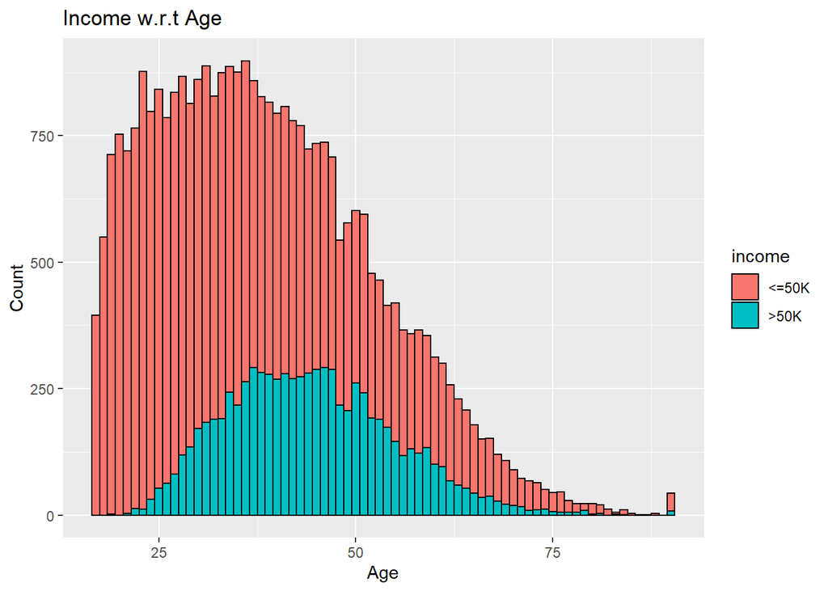

```r
library(ggplot2)
ggplot(adult3) + aes(x=as.numeric(age), group=income, fill=income) +
  geom_histogram(binwidth=1, color='black')+
  labs(x="Age",y="Count",title = "Income w.r.t Age")
```

As we notice majority of the people make less than <50k a year. However, we observe people earning >50k are in their mid career. We make this hypothesis based on the age.

Let’s check the same for workclass

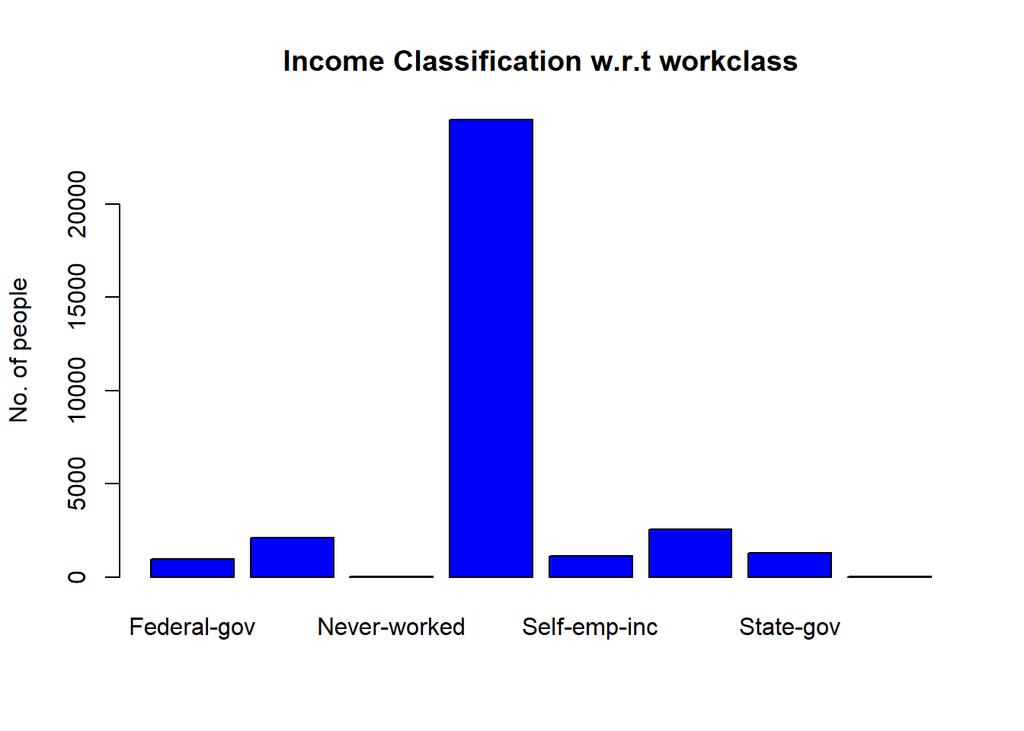

```r
barplot(table(adult3$workclass),main = 'Income Classification w.r.t workclass',col='blue',ylab ='No. of people')
```